# 4 - Landscape and genetic graph comparison with `graph4lg`

UMR 6049 ThéMA - CNRS - Univ. Marie et Louis Pasteur, Besançon, France

Paul SAVARY

# Introduction

The rationale of the `graph4lg` package in R is to make the construction and analysis of genetic and landscape graphs easier for landscape genetic studies (hence the name `graph4lg`, meaning Graphs for Landscape Genetics). This package provides users with tools for:

- Landscape and genetic data processing
- Genetic graph construction and analysis
- Landscape graph construction and analysis
- Landscape and genetic graph comparisons

Each one of the included vignettes focuses on one of these points. This fourth and last vignette will focus on **landscape and genetic graph comparisons**. It will describe the package functions allowing users to:

- Compare node metrics
- Compare graph links
- Compare graph modules

## Data used in this vignette

We will also use Graphab projects already created for the vignettes.

In landscape genetics, the analysis of the relationship between landscape and genetic data can be performed at **several scales**. Indeed, **node-, link-, neighbourhood-** and **boundary-based analyses** are distinguished (Wagner and Fortin 2013). Similarly, we can compare **landscape and genetic graphs** at these different scales, in particular when they share the same nodes. We present **how to implement these comparisons using `graph4lg`**. To see how to create landscape and genetic graphs with `graph4lg`, we invite users to read the second and third tutorials included in this package.

# Comparing node metrics

First, landscape and genetic graphs can be compared by **comparing connectivity metrics** measured at the level of a habitat patch (landscape graph node) with the genetic response of the population living and sampled in this habitat patch (genetic graph node) in terms of genetic diversity and differentiation from the other populations. When using this approach, two graphs are similar if the **correlation coefficient** between the metric values calculated for the same nodes is high. This **correlation** would be **interpreted as an evidence for the influence of habitat connectivity on population genetic structure**.

The function `graph_node_compar` computes these correlations to **compare two graphs at the node level**. It takes as arguments:

- `x`: A graph object of class `igraph`, i.e., the name of the first graph involved in the comparison. Its nodes must have the same names as in graph `y`.
- `y`: A graph object of class `igraph`, i.e., the name of the second graph involved in the comparison, sharing its nodes with graph `x`.
- `metrics`: A two-element character vector specifying the names of the node attributes from graphs `x` and `y` respectively, whose values will be used to assess their correlation. If these metrics are not within the node attributes, graph-theoretic metrics can be computed, such as:
  - Degree (`"deg"`),
  - Closeness centrality (`"close"`),
  - Betweenness centrality (`"btw"`),
  - Strength (`"str"`),
  - Sum of inverse strength (`"siw"`),
  - Mean of inverse link weight (`"miw"`).
- `method`: A character string indicating which type of correlation coefficient is to be computed:
  - Spearman’s rho (`method="spearman"`,default)
  - Pearson’r (`method="pearson"`),
  - Kendall’s tau (`method="kendall"`)
- `weight`: If new metrics are computed (see above), a logical (`TRUE` or `FALSE`) indicating whether the links are weighted during the calculation of the betweenness and closeness centrality indices. Link weights are interpreted as distances when computing the shortest paths.
- `test`: A logical (`TRUE` or `FALSE`) which indicates whether a significance test is performed

In order to include node attributes in the correlation, users can use compute them and associate them with graph nodes with `add_nodes_attr` function (described in vignette 2).

In the following example, we will import a landscape graph made of the habitat patches occupied by the 50 populations used in a gene flow simulation with CDPOP (`pts_pop_simul` and `data_simul_genind` data set). A genetic graph will be created from the simulated genetic data set. We will then compare two metrics computed at the node-level in these graphs.

`land_graph` is the landscape graph made of the forest habitat patches occupied by the 50 populations. Its 1225 links are weighted by cost-distances between patches (`mat_ld`). It is a complete graph.

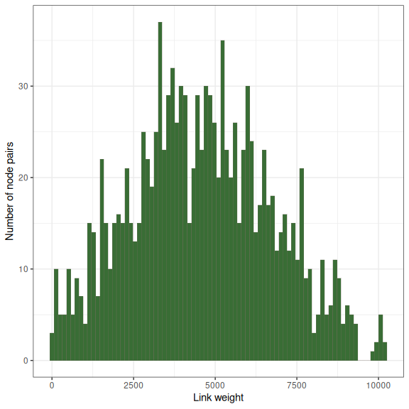

```r
land_graph <- gen_graph_topo(mat_w = mat_ld,
                             mat_topo = mat_ld,
                             topo = "comp")

# Plot the histogram of its link weights
plot_w_hist(graph = land_graph)
```

Using the function `plot_w_hist`, we see that its link weights almost follow a normal distribution with values ranging from 0 to 10,000 cost-distance units.

We will compute the mean of the inverse weight of every link connected to its nodes. This metric `miw` is akin to the Flux metric computed in Graphab. It takes high values if a patch is well connected and close to other patches. We use the function `compute_node_metric`:

```r
miw_lg <- compute_node_metric(graph = land_graph, metrics = "miw")
print(head(miw_lg))
```

```
#>   ID          miw
#> 1  1 0.0002740693
#> 2 10 0.0003191601
#> 3 11 0.0002856777
#> 4 12 0.0003549221
#> 5 13 0.0003657414
#> 6 14 0.0011067178
```

We include the values of this metric as a graph node attribute with the function `add_nodes_attr`:

```r
land_graph <- add_nodes_attr(graph = land_graph,
                             input = "df",
                             data = miw_lg,
                             index = "ID")
```

We now create a genetic graph from the simulated data set. For that purpose, we first compute a genetic distance matrix using the D<sub>PS</sub> genetic distance.

```r
mat_dps <- mat_gen_dist(x = data_simul_genind, dist = "DPS")
```

We use this distance matrix to create a complete genetic graph with `gen_graph_topo`:

```r
gen_comp_graph <- gen_graph_topo(mat_w = mat_dps,
                                 mat_topo = mat_dps,
                                 topo = "comp")
```

We plot the distribution of the link weights.

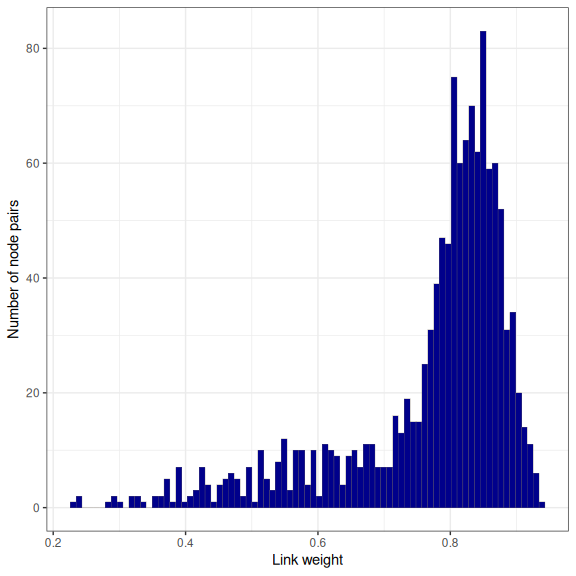

```r
plot_w_hist(graph = gen_comp_graph,
            fill = "darkblue")
```

We will compute the mean of the inverse weights of links connected to each node in the genetic graph `gen_comp_graph` and include it as a node attribute.

```r
miw_comp <- compute_node_metric(graph = gen_comp_graph, metrics = "miw")
gen_comp_graph <- add_nodes_attr(graph = gen_comp_graph,
                                 input = "df",
                                 data = miw_comp,
                                 index = "ID")
```

We can now **assess the correlation between these two metrics** using `graph_node_compar`:

```r
graph_node_compar(x = land_graph, y = gen_comp_graph,
                  metrics = c("miw", "miw"), method = "spearman",
                  weight = TRUE, test = TRUE)
```

```
#> [[1]]
#> [1] "Metric from graph x: miw"
#>
#> [[2]]
#> [1] "Metric from graph y: miw"
#>
#> [[3]]
#> [1] "Method used: spearman's correlation coefficient"
#>
#> [[4]]
#> [1] "Sample size: 50"
#>
#> [[5]]
#> [1] "Correlation coefficient: 0.723793517406963"
#>
#> [[6]]
#> [1] "p-value of the significance test: 2.86499806974383e-09"
```

The two metrics are **highly correlated**, meaning that if a habitat patch is well connected, the population occupying this patch is less different from the other populations from a genetic point of view than if the habitat patch is not well connected. This is quite an expected result given that gene flow was largely driven by cost-distances between populations during the genetic simulations.

Using complete graphs, visual representations are unclear because of link overlap. Building a Gabriel graph is a way to simplify graph topology. Gabriel graphs links will be computed from the Euclidean geographical distances between populations.

```r
mat_geo <- mat_geo_dist(data = pts_pop_simul,
                        ID = "ID", x = "x", y = "y")
```

```
#> Coordinates were treated as projected coordinates. Check whether
#>               it is the case.
```

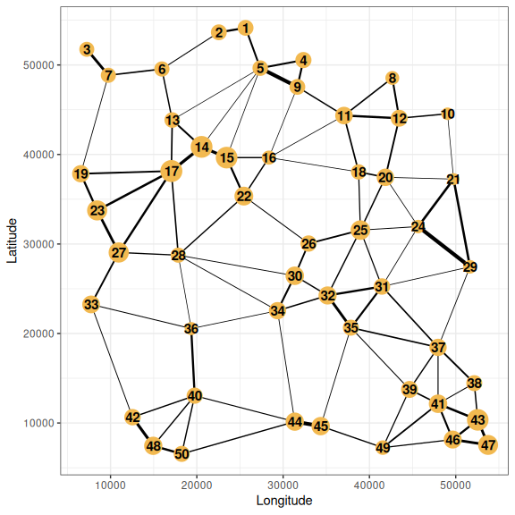

```r
mat_geo <- reorder_mat(mat_geo, order = row.names(mat_dps))

gen_gab_graph <- gen_graph_topo(mat_w = mat_dps,
                                mat_topo = mat_geo,
                                topo = "gabriel")

# Associate the values of miw from the complete graph to this graph

gen_gab_graph <- add_nodes_attr(gen_gab_graph,
                                data = miw_comp,
                                index = "ID")

# Plot the graph with node sizes proportional to MIW

plot_graph_lg(graph = gen_gab_graph,
              crds = pts_pop_simul,
              mode = "spatial",
              node_size = "miw",
              link_width = "inv_w")
```

# Comparing graph links

Another way to compare genetic and landscape graphs is to **compare their links**, thereby focusing on their **topology**. Two graphs are similar if the conserved links of one graph are the same ones as those conserved in the other. We included two functions allowing such comparisons.

The `graph_topo_compar` function **compares the topologies of two graphs sharing the same nodes**. To do that, it creates a contingency table whose modalities are “Presence of a link” and “Absence of a link”. We consider the topology of one graph to represent the “reality” of the dispersal flows that the other one is supposed to reproduce. In the (double entry) contingency table, when there is a 10 in the cell “Presence of a link” $\times$ “Presence of a link”, this means that 10 links between the same population pairs are present in the two compared graphs. The 10 value corresponds to the number of true positives (TP). The three other values of the table are the number of false positives (FP), true negatives (TN) and false negatives (FN). From this table, we can compute several **metrics often used to evaluate the performance of classification methods**: the Matthews’ correlation coefficient (Matthews 1975), the Kappa index, the False Discovery Rate, the Accuracy, the Sensitivity, the Specificity and the Precision.

The function takes as arguments:

- `obs_graph`: A graph object of class `igraph` with $n$ nodes. It is the observed graph that `pred_graph` is supposed to approach.
- `pred_graph`: A graph object of class `igraph` with $n$ nodes. It is the predicted graph that is supposed to be akin to `obs_graph`.
- `mode`: A character string specifying which index to compute in order to compare the topologies of the graphs: Matthews’ correlation coefficient (`mode="mcc"`, default), Kappa index (`mode="kappa"`), False Discovery Rate (`mode="fdr"`), Accuracy (`mode="acc"`), Sensitivity (`mode="sens"`), Specificity (`mode="spec"`) and Precision (`mode="prec"`).

For example, we will create a landscape graph from the cost-distance matrix using a threshold of 2000 cost-distance units and then compare the topology of this graph to that of the Gabriel graph created from the same nodes by computing the **Matthews’ correlation coefficient**.

We first create the thresholded landscape graph and plot it

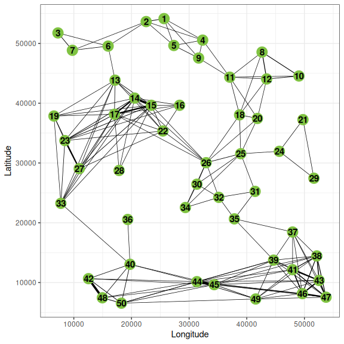

```r
land_graph_thr <- gen_graph_thr(mat_w = mat_ld, mat_thr = mat_ld,
                             thr = 2000, mode = "larger")

plot_graph_lg(land_graph_thr,
              mode = "spatial",
              crds = pts_pop_simul,
              link_width = "inv_w",
              pts_col = "#80C342")
```

We then compare the topology of `land_graph_thr` and `gen_gab_graph` using the Matthews’ correlation coefficient using `graph_topo_compar`:

```r
graph_topo_compar(obs_graph = land_graph_thr,
                  pred_graph = gen_gab_graph,
                  mode = "mcc",
                  directed = FALSE)
```

```
#> Matthews Correlation Coefficient : 0.541875568864072
#> [1] 0.5418756
```

We get a Matthews’ correlation coefficient of 0.54. This coefficient takes a value of 0 when the matches between topologies are no more frequent than by chance alone. It reaches 1 when the topologies are identical.

Besides, we can **visually compare the topologies** of two graphs sharing the same nodes. For that purpose, their links are displayed on a map with a **color depending on their presence in both graphs or in only one of them**. The `graph_plot_compar` function can be used. It takes as arguments:

- `x`: A graph object of class `igraph`, i.e., the name of the first graph involved in the comparison. Its nodes must have the same names as in graph `y`.
- `y`: A graph object of class `igraph`, i.e., the name of the second graph involved in the comparison, sharing its nodes with graph `x`.
- `crds`: A `data.frame` with the spatial coordinates of the graph nodes (both `x` and `y`). It must have three columns: ID, x, and y.

For example:

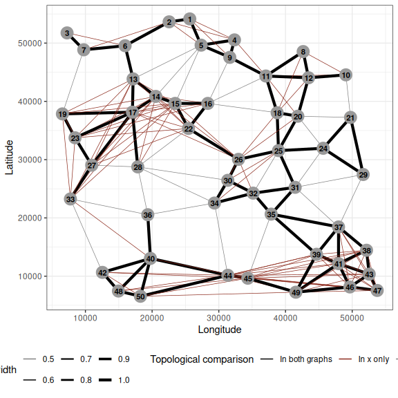

```r
graph_plot_compar(x = land_graph_thr, y = gen_gab_graph,
                  crds = pts_pop_simul)
```

This representation clearly indicates where are the shared and unshared links.

# Comparing graph modules

Finally, two graphs have similar topological and connectivity properties if their modules match, i.e., if two nodes classified together in the same module when the partition in modules is computed from one graph are also classified together in the same module when the partition is computed from the other graph.

The `graph_modul_compar` function **compares the nodes’ partitions into modules**. To do that, it computes the **Adjusted Rand Index (ARI)** (Hubert and Arabie 1985), a standardised index which counts the number of node pairs classified in the same module in both graphs. The function also performs the nodes partition into modules by using the modularity calculations available in `igraph` package. We can specify the algorithm used to compute the modularity, the link weighting scheme, the number of modules, among others. It takes as arguments:

- `x`: A graph object of class `igraph`, i.e., the name of the first graph involved in the comparison. Its nodes must have the same names as in graph `y`.
- `y`: A graph object of class `igraph`, i.e., the name of the second graph involved in the comparison, sharing its nodes with graph `x`.
- `mode`: The type of input data, which can be `"graph"` or `data.frame` or `vector` (see help file `?graph_modul_compar` for more details).
- `nb_modul`: A numeric or integer value or a numeric vector with 2 elements indicating the number of modules to create in both graphs. By default, this number is the number of modules maximising modularity index.
- `algo`: A character string indicating the algorithm used to create the modules with `igraph`, among: `"fast_greedy"` (default), `"walktrap"`, `"louvain"`, `"optimal"`.
- `node_inter`: A character string indicating whether the links of the graph are weighted by distances or by similarity indices. It is only used to compute the modularity index. It can be:
  - `'distance'`: Link weights correspond to distances. Nodes that are close to each other will more likely be in the same module.
  - `'similarity'`: Link weights correspond to similarity indices. Nodes that are similar to each other will more likely be in the same module. Inverse link weights are then used to compute the modularity index.
  - `'none'`: Links are not weighted for the computation, which is only based on graph topology.

Two different weighting schemes can be used to create the modules of the two graphs:

- If `node_inter` is a character string, then the same link weighting is used for both graphs.
- If `node_inter` is a character vector of length 2, then the link weighting used by the algorithm to create the modules of graphs `x` and `y` is determined by the first and second elements of `node_inter`, respectively.

In the following example, we compare `land_graph_thr` and `gen_gab_graph` with the default parameters (`algo='fast_greedy'` algorithm, optimal number of modules, links weighted by inverse distances (`node_inter="distance"`)).

```r
graph_modul_compar(x = land_graph_thr,
                   y = gen_gab_graph)
```

```
#> [1] "7 modules in graph 1 and 6 modules in graph 2"
#> [1] "Adjusted Rand Index: 0.648832401029973"
#> [1] 0.6488324
```

The ARI value is relatively high meaning that modules are somehow similar.

We can **check this result visually**. We first compute the modules in both graphs and include them as node attributes.

```r
module_land <- compute_graph_modul(graph = land_graph_thr,
                                   algo = "fast_greedy",
                                   node_inter = "distance")

land_graph_thr <- add_nodes_attr(graph = land_graph_thr,
                                 data = module_land,
                                 index = "ID")

module_gen <- compute_graph_modul(graph = gen_gab_graph,
                                   algo = "fast_greedy",
                                   node_inter = "distance")

gen_gab_graph <- add_nodes_attr(graph = gen_gab_graph,
                                 data = module_gen,
                                 index = "ID")
```

We then plot both graphs, colouring their nodes depending on their module:

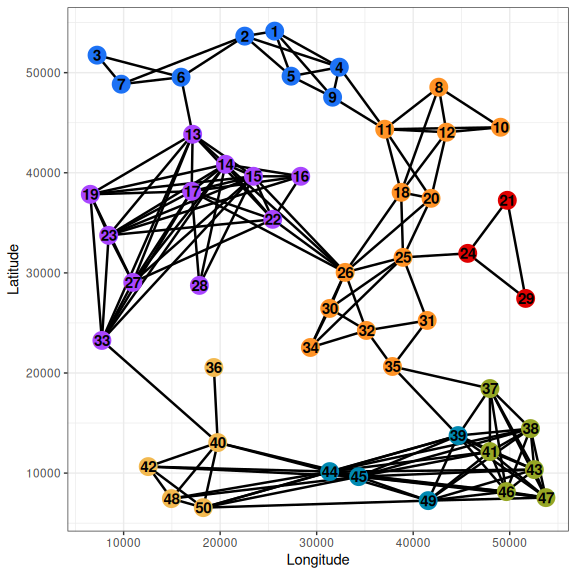

```r
plot_graph_lg(graph = land_graph_thr,
              mode = "spatial",
              crds = pts_pop_simul,
              module = "module")
```

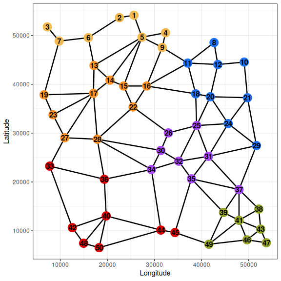

```r
plot_graph_lg(graph = gen_gab_graph,
              mode = "spatial",
              crds = pts_pop_simul,
              module = "module")
```

We easily visualise divergence and convergence in both module partitions.

# References

Foltête, Jean-Christophe, Céline Clauzel, and Gilles Vuidel. 2012. “A Software Tool Dedicated to the Modelling of Landscape Networks.” *Environmental Modelling & Software* 38: 316–27.

Hubert, Lawrence, and Phipps Arabie. 1985. “Comparing Partitions.” *Journal of Classification* 2 (1): 193–218.

Landguth, Erin L, and SA Cushman. 2010. “CDPOP: A Spatially Explicit Cost Distance Population Genetics Program.” *Molecular Ecology Resources* 10 (1): 156–61.

Matthews, Brian W. 1975. “Comparison of the Predicted and Observed Secondary Structure of T4 Phage Lysozyme.” *Biochimica Et Biophysica Acta (BBA)-Protein Structure* 405 (2): 442–51.

Wagner, Helene H, and Marie-Josée Fortin. 2013. “A Conceptual Framework for the Spatial Analysis of Landscape Genetic Data.” *Conservation Genetics* 14 (2): 253–61.